# System Calling Conventions for Interfacing with Assembly

Intel Linux and Windows Calling Conventions

Jason Curl

2023-10-07

# 1 Software Calling Conventions - Foreword

I wrote this document initially in October 2012 using LaTeX. I was motivated by how to implement a calling convention in assembly, so I could write functions in assembly and link with my C libraries. The work was for my RJCP.DLL.CpuId project.

Now 10 years have passed, and I’d like to publish my original work. As part of that effort, I wanted to convert it to Markdown format, which has become immensely popular with the usage of [GitHub](https://github.com/) and [BitBucket](https://bitbucket.org/product) for rendering within the browser. The [Visual Studio Code](https://code.visualstudio.com/) editor makes it easy to write markdown with its preview mode and various plugins. Tools such as [pandoc](https://pandoc.org/) make great strides in making markdown a publishable format.

By all means, I wouldn’t call it professional, but sufficiently good enough to support myself in my own work.

Since this document was first written, Linux distributions are now generally 64-bit and ARM processors have become more ubiquitous for mainstream use. Work may be extended later to include more information.

## 1.1 Copyright

Copyright (C) 2012 - 2024, Jason Curl

## 1.2 Revision History

| Date | Revision |
| --- | --- |
| 2012-11-10 | First version using LaTeX |
| 2022-01-30 | Converted to Markdown, build with Pandoc |
| 2023-10-07 | Add Type Models |
| 2024-04-20 | Update for AARCH64 |

# 2 Introduction

Calling conventions are the rules that allow different software components, written by different software vendors, potentially using different compilers or different languages, to interface with one another.

In this paper you’ll find examples of how compilers implement the calling conventions. It does not replace the standards themselves. There is a lot of information on the Internet but unfortunately, some of the terminology used is not clear (ordering left to right, or right to left), they lack significant details (variable argument lists, structures, floats) or need examples.

The code examples presented are in C. The output is disassembled by various tools, dependent on the system that’s being run. For example, the `dumpbin.exe` tool is used for Microsoft generated objects. On Unix type systems the tool `objdump` is used.

## 2.1 Definitions, Acronyms and Abbreviations

| Abbreviation | Meaning |
| --- | --- |
| ABI | Application Binary Interface |
| AMD | Advanced Micro Design, Chip manufacturer producing Intel compatible CPUs and owning 64-bit extensions bit Binary Digit |
| callee | Function code that is being called |
| caller | Code that calls a function |
| cdecl | C Declaration calling convention |
| CPU | Central Processing Unit |
| GHz | Gigahertz, or 1 million cycles per second |
| Intel | Microchip and CPU manufacturer |
| MSR | Machine Specific Register |
| RAM | Random Access Memory |
| stdcall | Standard Calling Convention |
| SVN | Subversion Revision Control System |
| UUID | Universally Unique Identifiers |
| x86 | Intel 80x86 32-bit compatible instruction set |
| x64 | AMD 80x86 64-bit compatible instruction set |

## 2.2 Typographical Conventions

This document is prepared using the Markdown format. Screen information is provided as monospaced text blocks. Default markdown code formatting is used for code syntax highlighting.

# 3 Programming Models

## 3.1 32-bit and 64-bit Environment Modes

There are three 64-bit programming models, depending on the Operating System and architecture that is targetted. This information is useful when writing cross-platform software.

|  | char | short | int | long | long long | void * |
| --- | --- | --- | --- | --- | --- | --- |
| ILP64 | 8 | 16 | 64 | 64 | 64 | 64 |
| LP64 | 8 | 16 | 32 | 64 | 64 | 64 |
| LLP64 / P64 | 8 | 16 | 32 | 32 | 64 | 64 |
| ILP32 | 8 | 16 | 32 | 32 | 64 | 32 |
| LP32 | 8 | 16 | 16 | 32 | 64 | 32 |

- ILP64 is `int`, `long` and `long long`, and pointers are 64-bit.
- LP64 is `long` and `long long`, as well as pointers are 64-bit, `int` is 32-bits wide.
- LLP64 is `long long` and pointers are 64-bit.

When referring to the C-Standard:

> For any two integer types with the same signedness and different integer conversion rank, the range of values of the type with smaller integer conversion rank is a subrange of the values of the other type."

and further in the document

> "The rank of `long long int` shall be greater than the rank of `long int`, which shall be greater than the rank of `int`, which shall be greater than the rank of `short int`, which shall be greater than the rank of `signed char`.

The [CPP Reference](https://en.cppreference.com/w/cpp/language/types) lists the types as well.

### 3.1.1 Models used by OSes

| OS | Processor | Model 64-bit | Model 32-bit | Struct Pack |
| --- | --- | --- | --- | --- |
| Windows 3.1 | Intel | - | LP32 |  |
| MacOS Classic | 68k | - | LP32 |  |
| Windows NT | ARM, Intel | LLP64 | ILP32 | 8 (x86, ARM, ARM64), 16 (x64, ARM64EC) |
| Linux | ARM, Intel | LP64 | ILP32 |  |
| Free/OpenBSD | ARM, Intel | LP64 | ILP32 |  |
| MacOS X | ARM, Intel | LP64 | ILP32 |  |
| Solaris | Intel, Sparc | LP64 | ILP32 |  |

Note that [ARM64EC](https://learn.microsoft.com/en-us/windows/arm/arm64ec) is an ABI that specifies ARM64 Emulation Compatible for Windows 11 and later, to have the same software calling conventions of x64.

References:

- [Windows](https://learn.microsoft.com/en-us/cpp/build/reference/zp-struct-member-alignment)

### 3.1.2 Alignment of Fields in a Struct

On Windows (ARM and Intel), the compiler aligns class and struct members on their size value: `bool` and `char` on 1-byte boundaries, `short` on 2-byte boundaries, `int`, `long`, and `float` on 4-byte boundaries, and `long long`, `double`, and `long double` on 8-byte boundaries. This matches also the size of the datatypes for ILP32 and LLP64 so that alignment is on boundaries multiple of the datasize type.

On Linux, the alignment of structs depends on the alignment of the largest type in the structure, so as to guarantee all fields in the struct are natively aligned.

Motorola 68k processors had alignment on 2-byte boundaries (even 32-bit values can be aligned on 32-bit without penalty).

References:

- [Windows](https://learn.microsoft.com/en-us/cpp/cpp/alignment-cpp-declarations)

# 4 Intel Architecture

## 4.1 Intel Architecture for 32-bit

A summary of the registers and conventions are given here as a refresher. Readers wanting more information should refer to the documentation by Intel.

### 4.1.1 32-bit Registers

There are 8 general purpose registers for 32-bit Intel processors:

- `EAX` - Accumulator
- `EBX` - Base register; pointer to data in the DS segment
- `ECX` - Counter register (for counter, shift and loop operations)
- `EDX` - Data register, I/O pointer
- `ESP` - Stack Pointer, in the SS segment
- `EBP` - Stack frame Base Pointer (also related to the SS segment)
- `ESI` - Source Index register for string operations. Pointer to data provided by the DS segment
- `EDI` - Destination Index register for string operations. Pointer to data provided by the ES segment.

Other important registers are:

- `EIP` - Instruction Pointer
- `FLAGS` - Condition codes

The equivalent 16-bit portions of the registers are: `AX`, `BX`, `CX`, `DX`, `SP`, `BP`, `SI`, `DI`, and `IP`. The 8-bit registers are (`H` high byte; `L` low byte): `AL`, `AH`, `BL`, `BH`, `CL`, `CH`, `DL`, `DH`, `SIL` and `DIL`. There is no 8-bit equivalent for `SP`, `BP` and `IP`.

The list of segment registers are:

- `CS` - Code Segment
- `DS` - Data Segment
- `SS` - Stack Segment
- `ES` - Extra Segment (Data segment)
- `FS` - F Segment (Data segment), from 80386 and later
- `GS` - G Segment (Data segment), from 80386 and later

The 80-bit FPU registers are overlaid with the 64-bit MMX registers

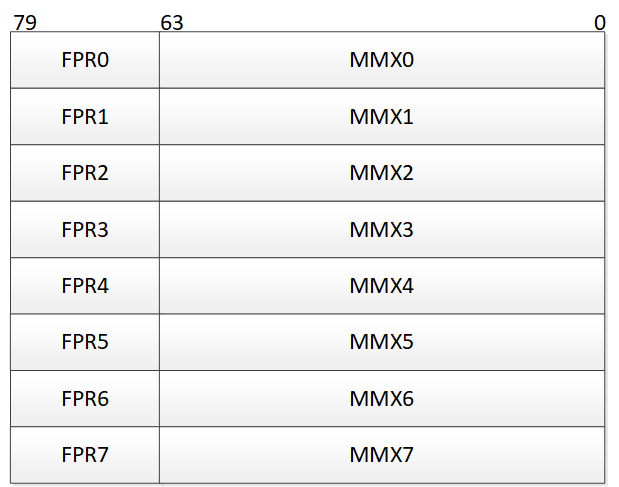

IA32 MMX

There are also 8 general purpose SSE registers: `XMM0`, `XMM1`, `XMM2`, `XMM3`, `XMM4`, `XMM5`, `XMM6` and `XMM7`.

### 4.1.2 Stack Frames

There are two implementations of a stack frame seen when disassembling code. One based on the stack pointer (`ESP`), the other implementation based on the stack frame base pointer (`EBP`). The offsets in the following figures are relative to the code in the callee.

#### 4.1.2.1 ESP Based Stack Frames

The stack frame described below indicates generally the offsets referenced from the `ESP` stack pointer. Many compilers (e.g. GCC with the option `-fomit-frame-pointers`) generate such stack frames as part of their optimisation to reduce code size. Some debuggers however are not able to show stack information for code compiled.

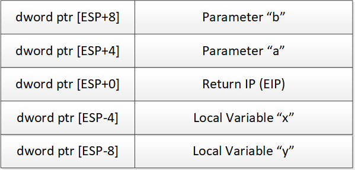

ESP Based Stack Frame

#### 4.1.2.2 EBP Based Stack Frames

The normal practice for unoptimized code generation is to use the `EBP` register as the stack frame pointer. The callee is generally responsible for preserving the `EBP` register so it is unchanged on exit. The equivalent stack frame based on `EBP` is provided below:

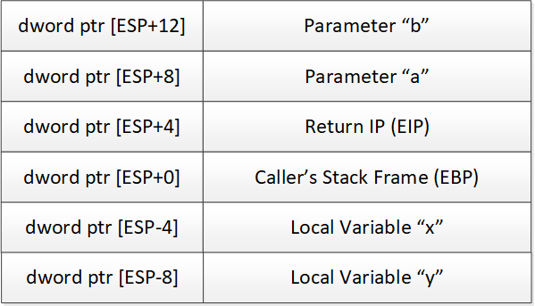

EBP Based Stack Frame

The callee usually has the following prologue:

```
  10001000: 55                 push        ebp
  10001001: 8B EC              mov         ebp,esp
```

And the epilogue is one of the following:

[output not shown]

or

```
  10001010: C9                 leave
  10001011: C2 08 00           ret         8
```

## 4.2 Intel Architecture for 64-bit

### 4.2.1 64-bit Registers

There are considerably more general purpose registers available on 64-bit AMD processors. The general purpose registers are:

- `RAX`, `RBX`, `RCX`, `RDX` which are 64-bit extensions of the 32-bit `EAX`, `EBX`, `ECX`, `EDX`
- `RBP`, `RDI`, `RSI` which are 64-bit extensions of the 32-bit `EBP`, `EDI`, `ESI`
- `R8`, `R9`, `R10`, `R11`, `R12`, `R13`, `R14`, `R15` are new. 32-bit, 16-bit and 8-bit variants are accessed via `RnD`, `RnW`, `RnB` respectively.
- `RSP` which are 64-bit extensions to the 32-bit `ESP`

Other important registers are:

- `RIP` - 64-bit Instruction Pointer
- `FLAGS` - Condition codes

The list of segment registers remain. They are mostly unused in the 64-bit model. The segment registers `FS` and `GS` can have the upper 32-bits set through `MSRs`.

- `CS` - Code Segment (ignored)
- `DS` - Data Segment (ignored)
- `SS` - Stack Segment (ignored)
- `ES` - Extra Segment (ignored)
- `FS` - F Segment (Data segment)
- `GS` - G Segment (Data segment)

To quote [AMD](http://stackoverflow.com/questions/8284756/ia-32e-64-bit-idt-gate-descriptor):

> Segmentation is disabled in 64-bit mode, and code segments span all of virtual memory. In this mode, code-segment base addresses are ignored. For the purpose of virtual-address calculations, the base address is treated as if it has a value of zero. Data segments referenced by the `FS` and `GS` segment registers receive special treatment in 64-bit mode. For these segments, the base address field is not ignored, and a non-zero value can be used in virtual-address calculations. A 64-bit segment-base address can be specified using model specific registers. Unlike the `CS`, `DS`, `ES`, and `SS` segments, the `FS` and `GS` segment overrides can be used in 64-bit mode. When `FS` and `GS` segment overrides are used in 64-bit mode, their respective base addresses are used in the effective-address (EA) calculation. The complete EA calculation then becomes (`FS` or `GS`)`.base + base + (scale + index) + displacement`. The `FS.base` and `GS.base` values are also expanded to the full 64-bit virtual-address size. The resulting EA calculation is allowed to wrap across positive and negative addresses.

[Wikipedia](http://en.wikipedia.org/wiki/X86_memory_segmentation) has information about the usage of the `GS` segment register

> Microsoft Windows 64-bit uses the `GS` segment to point to the Thread Environment Block, a small data structure for each thread, which contains information about exception handling, thread- local variables, and other per-thread state. Similarly, the Linux kernel uses the `GS` segment to store per-CPU data.

The MMX registers continue to exist as is for 32-bit. There are in addition 8 new XMM registers: `XMM8`, `XMM9`, `XMM10`, `XMM11`, `XMM12`, `XMM13`, `XMM14` and `XMM15`.

## 4.3 Flags

The flags register contains the results of various operations. To summarise, the following flags are defined

| Bit | Flag | Description |
| --- | --- | --- |
| 0 | CF(S) | Carry Flag: Set if the last arithmetic operation carried (addition) or borrowed (subtraction) a bit beyond the size of the register. This is then checked when the operation is followed with an add-wit… |
| 2 | PF(S) | Parity Flag. Set if the number of bits in the least significant byte of the result is a multiple of 2. |
| 4 | AF(S) | Adjust Flag. Carry of Binary Code Decimal (BCD) numbers arithmetic operations. This is the carry or borrow of bit 3 of the result for BCD arithmetic. |
| 6 | ZF(S) | Zero Flag. Set if the result of an operation is Zero (0). |
| 7 | SF(S) | Sign Flag. Set if the result of an operation is negative. |
| 8 | TF(X) | Trap Flag. Set if step by step debugging. |
| 9 | IF(X) | Interruption Flag. Set if interrupts are enabled. |
| 10 | DF(C) | Direction Flag. Stream direction. If set, string operations will decrement their pointer rather than incrementing it, reading memory backwards.Setting the DF flag causes the string instructions to aut… |
| 11 | OF(S) | Overflow Flag. Set if signed arithmetic operations result in a value too large for the register to contain. |
| 12, 13 | IOPL(X) | I/O Privilege Level field (2 bits). I/O Privilege Level of the current process. |
| 14 | NT(X) | Nested Task flag. Controls chaining of interrupts. Set if the current process is linked to the next process. |
| 16 | RF(X) | Resume Flag. Response to debug exceptions |
| 17 | VM(X) | Virtual-8086 Mode. Set if in 8086 compatibility mode. |
| 18 | AC(X) | Alignment Check. Set if alignment checking of memory references is done. |
| 19 | VIF(X) | Virtual Interrupt Flag. Virtual image of IF. |
| 20 | VIP(X) | Virtual Interrupt Pending flag. Set if an interrupt is pending. |
| 21 | ID(X) | Identification Flag. Support for CPUID instruction if can be set. |

where:

- S is a Status Flag
- C is a Control Flag
- X is a System Flag

### 4.3.1 Condition Names

Condition names are those used in instructions for testing and jumping. The conditions are based on the `FLAGS` register described in the table above.

| Condition | Flags | Meaning |
| --- | --- | --- |
| Z | ZF=1 | Result of last operation was zero |
| NZ | ZF=0 | Result of last operation was not zero |
| C | CF=1 | Last operation required a carry or borrow. For unsigned integers, this indicates an overflow |
| NC | CF=0 | Last operation did not require a carry or borrow. For unsigned integers, this indicates that no overflow occurred |
| S | SF=1 | Result of last operation has its high bit set. |
| NS | SF=0 | Result of last operation has its high bit clear. |
| O | OF=1 | When treated as a signed integer operation, the last operation caused an overflow or underflow. |
| NO | OF=0 | When treated as signed integer operation, the last operation did not cause an overflow or underflow. |

The following conditions are to be interpreted after a `CMP` operation.

| Condition | Flags | Meaning |
| --- | --- | --- |
| E | ZF=1 | Equal. value1 == value2. |
| NE | ZF=0 | Not Equal. value1 != value2. |
| GE / NL | SF=OF | Greater or Equal / Not Lower. value1 >= value2. |
| LE / NG | ZF=1 or SF!=OF | Less or Equal / Not Greater. value1 <= value2. |
| G / NLE | ZF=0 and SF=OF | Greater / Not Lower or Equal. value1 > value2. |
| L / NGE | SF!=OF | Lower / Not Greater or Equal. value1 < value2. |
| AE / NB | CF=0 | Above or Equal, Not Below. value1 >= value2. |
| BE / NA | CF=1 or ZF=1 | Below or Equal / Not Above. value1 <= value2. |
| A / NBE | CF=0 and ZF=0 | Above / Not Below or Equal. value1 > value2. |
| B / NAE | CF=1 | Below / Not Above or Equal. value1 < value2 |

## 4.4 Word Sizes

The following word sizes are used in this document, especially when describing stack frames.

| Mnemonic | Size |
| --- | --- |
| `word` | 2 bytes |
| `dword` | 4 bytes (double word) |
| `qword` | 8 bytes (quad word) |
| `oword` | 16 bytes (octal word) |
| `yword` | 32 bytes (y word) |
| `zword` | 64 bytes (z word) |

# 5 ARM Architecture

## 5.1 ARMv8-A with A64 Instruction Set

This page is a short summary of the most important parts of the ARMv8-A A64 instruction set. It is only intended for a quick reference, where [ARM Developer Documentation](https://developer.arm.com/documentation) contains very good references.

### 5.1.1 General Purpose Registers

There are 31 general purpose registers (called `Rx`):

- `X0` - `X30` indicate 64-bit usage.
- `W0` - `W30` indicate 32-bit usage with the upper 32-bits cleared.

Aliases for registers:

- `X30` is used as the *Link Register*, also referred to as `LR`.
- `X29` is used as the *Frame Pointer Register*, also referred to as `FP`.

Register 31 is either referenced as the stack pointer (`SP`, which is dependent on the privilege level, and not considered general purpose) or `XZR` / `WZR` for reading zero.

### 5.1.2 Floating Point Registers

There are 32 general purpose floating point registers (called `Vx`):

- `Q0` - `Q31` for 128-bit usage.
- `D0` - `D31` for 64-bit usage.
- `S0` - `S31` for 32-bit usage.
- `H0` - `H31` for 16-bit usage, FP16 since ARMv8.2-A (mandatory in ARMv9-A), BF16 since ARMv8.2-A (mandatory in ARMv8.6-A).
- `B0` - `B31` for 8-bit (FP8) usage, since ARMv9.2-A.

Properties of the floating point types:

| Type | Exponent Size | Mantissa |
| --- | --- | --- |
| Quadword, 128-bit | 15 | 112 |
| Double, 64-bit | 11 | 52 |
| Single, 32-bit | 8 | 23 |
| FP16, 16-bit | 5 | 10 |
| BF16, 16-bit | 8 | 7 |
| FP8, E5M2 | 5 | 2 |
| FP8, E4M3 | 4 | 3 |

### 5.1.3 Calling Conventions

| Register | Alias | Role in the Procedure Call Standard |
| --- | --- | --- |
| SP |  | Stack Pointer. Must be preserved between subroutines. |
| R30 | LR | Link Register. Must be preserved between subroutines. |
| R29 | FP | Frame Pointer. Must be preserved between subroutines. |
| R19..R28 |  | Callee-saved registers. Must be preserved between subroutines. |
| R18 |  | The Platform Register, if needed; else a temporary register. |
| R17 | IP1 | Second intra-procedure-call temporary register. |
| R16 | IP0 | First intra-procedure-call temporary register. |
| R9..R15 |  | Temporary registers. |
| R8 |  | Indirect result location register. |
| R0..R7 |  | Parameter / Result registers. Further parameters are put on the stack. |
| V0..V7 |  | Parameter / Result registers. Further parameters are put on the stack. |

# 6 Windows - Intel Architecture

In this part, we cover various used calling conventions used on Windows computers, particularly the Intel architecture (both 32-bit and 64-bit). Information is based on Visual Studio compilers.

The examples provided here are compiled using the Microsoft Visual Studio 2012 compilers using default settings (which provide generally for SSE2 type instructions). In some cases, the compiler has been configured to produce standard code with the `/arch:ia32` option.

## 6.1 stdcall: Standard Calling Convention

The `stdcall` calling convention is that which is specified for Windows DLLs through the `WINAPI` macro. the standard calling convention doesn’t support variable argument lists.

Examples provided here are generated using Microsoft Visual Studio 2012. Default settings are used for compiling the code. In some cases, a specific machine architecture is provided to disable SSE instructions (with the `/arch:ia32` option). Dumping of the object code in assembly is done using the Microsoft tool `dumpbin.exe`.

This tool shows code in the Microsoft Macro Assembler format (so that code is shown in the Intel syntax).

```
> set MSVC=C:\Program Files\Microsoft Visual Studio 11.0
> set PATH=%MSVC%\Common7\IDE;%MSVC%\VC\bin;%PATH%
> dumpbin test.exe /disasm /out:test.asm
```

### 6.1.1 Naming Convention

Functions exported for linking are prefixed with an underscore (`_`), followed by an at symbol (`@`) and the number of bytes the parameter list uses on the stack (in decimal). The following sections will have various examples on the naming convention. Listed below are some examples to illustrate the point:

- Three integers in parameter list

  `int myfunc(int a, int b, int c);`

  → `_myfunc@12`
- An empty parameter list

  `void myfuncv();`

  → `_myfuncv@0`
- Struct return by value

  `struct mystruct myfuncs();`

  → `_myfuncs@0`

  `struct mystruct myfuncs(int x, int y);`

  → `_myfuncs@8`
- Doubles

  `double myfuncs(double a, double b);`

  → `_myfuncs@16`

Windows compilers can be told to ignore the naming conventions, providing symbols that are named directly after the function without being decorated with parameter information. This is often useful for platform interoperability.

### 6.1.2 Parameter Passing and Return Values

Arguments are passed on the main stack (given by the register `ESP`):

- order is from right to left. That is, push the far right argument on the stack first, the first argument is then pushed last;
- floating point variables (double and float) are also pushed on the main stack given by `ESP` (not the FPU stack);
  - floats are 4 bytes, doubles are 8 bytes
- variable number of arguments (varargs) are not supported by the stdcall calling convention;
  - This is because the callee must clean up the stack.

Return values (8 bytes or less) are given on exit in registers:

- 32-bit integers are returned in the register `EAX`;
- 64-bit values are returned by `EDX:EAX` (e.g. like the result of the x86 `imul` instruction, where the lower 32-bits are in EAX and the upper 32-bits are in `EDX`);
- `float`s and `double`s are returned on the FPU stack (`ST(0)`).

Cleaning up the stack is done by the callee.

- This is typically done with the `ret` instruction which has an optional parameter to determine how many bytes to pop from the stack before returning. For example, if 24 bytes are pushed on the stack, then typically compilers produce `ret 24` and the end of the callee.
- Values returned on the stack are covered next

Returning structs by value that are greater than 64-bits are handled in a special manner and deserve explicit attention:

- The caller allocates space for the struct that is returned by value.

  This may look a little strange, when comparing how C programs are written, where the callee normally has code that would appear to allocate stack space instead.
- The caller then passes a pointer to the struct on the stack last, as if it were the first parameter.
- On return, EAX contains the pointer to the struct given in the first parameter.
- The callee is responsible for popping the pointer to the struct in addition.
- The function signature contains the number of bytes excluding the pointer to the struct, as seen here

  `struct mystruct myfuncs(int x, int y);`

  → `_myfuncs@8`

  So even though 12 bytes should be pushed on the stack (plus space should be allocated for the struct value in addition), the function signature shows only 8 bytes. The function still removes 12 bytes from the stack on returning with a `ret 12` instruction.

### 6.1.3 Scratch Registers

The following registers are considered scratch registers, the callee does not need to preserve them on exit. The caller should preserve these registers in case they’re needed on return.

- `EAX` - Return value for integers (lower 32-bits)
- `EDX` - Return value for 64-bit integers, otherwise don’t care
- `ECX`

All other registers must be preserved by the callee: `EBP`, `EBX`, `EDI`, `ESI`. Registers `EIP` and `ESP` need to be preserved as described earlier.

### 6.1.4 Examples

#### 6.1.4.1 Two Integers

The callee accepts two 4-byte (signed) integers. The caller is the function `DllMain`. The callee takes the parameters, adds a fixed value and multiplies them, so it’s visible in code which parameter is being referenced.

```c
CALLINGCONVENTION_API int __stdcall fnCallingConvention(int a, int b)
{
  return (a+1) * (b+2);
}

BOOL APIENTRY DllMain(HMODULE hModule, DWORD  ul_reason_for_call, LPVOID lpReserved)
{
  fnCallingConvention(1, 2);
  return TRUE;
}
```

```
_DllMain@12:
  100113B7: 6A 02              push        2
  100113B9: 6A 01              push        1
  100113BB: E8 86 FC FF FF     call        _fnCallingConvention@8

_fnCallingConvention@8:
  10001000: 55                 push        ebp
  10001001: 8B EC              mov         ebp,esp
  10001003: 8B 45 08           mov         eax,dword ptr [ebp+8]
  10001006: 8B 4D 0C           mov         ecx,dword ptr [ebp+0Ch]
  10001009: 40                 inc         eax
  1000100A: 83 C1 02           add         ecx,2
  1000100D: 0F AF C1           imul        eax,ecx
  10001010: 5D                 pop         ebp
  10001011: C2 08 00           ret         8
```

Observations:

The stackframe in the callee, based on EBP looks like:

| Offset | Value |
| --- | --- |
| `dword ptr [EBP+12]` | Parameter `b` |
| `dword ptr [EBP+8]` | Parameter `a` |
| `dword ptr [EBP+4]` | Callers `EIP` return address |
| `dword ptr [EBP]` | Callers `EBP` frame pointer |
| `xxx ptr [EBP-x]` | Local stack variables |

#### 6.1.4.2 Mixed Floats and Integers

A mix of floats and integers are passed to the callee, with an integer being returned

```c
CALLINGCONVENTION_API int __stdcall fnCallingConvention(float a, int b, float c, int d)
{
  return (a+1) * (b+2) * (c+3) * (d+4);
}

BOOL APIENTRY DllMain(HMODULE hModule, DWORD  ul_reason_for_call, LPVOID lpReserved)
{
  return fnCallingConvention(1, 2, 3, 4);
}
```

```
_DllMain@12:
  10001050: 6A 04              push        4
  10001052: 51                 push        ecx
  10001053: C7 04 24 00 00 40  mov         dword ptr [esp],40400000h
            40
  1000105A: 6A 02              push        2
  1000105C: 51                 push        ecx
  1000105D: C7 04 24 00 00 80  mov         dword ptr [esp],3F800000h
            3F
  10001064: E8 97 FF FF FF     call        _fnCallingConvention@16

_fnCallingConvention@16:
  10001000: 55                 push        ebp
  10001001: 8B EC              mov         ebp,esp
  10001003: 8B 45 0C           mov         eax,dword ptr [ebp+0Ch]
  10001006: F3 0F 10 4D 08     movss       xmm1,dword ptr [ebp+8]
  1000100B: F3 0F 58 0D B8 20  addss       xmm1,dword ptr [__real@3f800000]
            00 10
  10001013: 83 C0 02           add         eax,2
  10001016: 66 0F 6E C0        movd        xmm0,eax
  1000101A: 8B 45 14           mov         eax,dword ptr [ebp+14h]
  1000101D: 0F 5B C0           cvtdq2ps    xmm0,xmm0
  10001020: 83 C0 04           add         eax,4
  10001023: F3 0F 59 C8        mulss       xmm1,xmm0
  10001027: F3 0F 10 45 10     movss       xmm0,dword ptr [ebp+10h]
  1000102C: F3 0F 58 05 BC 20  addss       xmm0,dword ptr [__real@40400000]
            00 10
  10001034: F3 0F 59 C8        mulss       xmm1,xmm0
  10001038: 66 0F 6E C0        movd        xmm0,eax
  1000103C: 0F 5B C0           cvtdq2ps    xmm0,xmm0
  1000103F: F3 0F 59 C8        mulss       xmm1,xmm0
  10001043: F3 0F 2C C1        cvttss2si   eax,xmm1
  10001047: 5D                 pop         ebp
  10001048: C2 10 00           ret         10h
```

Observations:

- Floating point values are pushed on the stack with each taking 4 bytes in the same manner as integers. The compiler pushes the binary representation for the values 1.0 and 3.0. The register `ECX` is scratch and the instructions `push ecx` are equivalent to `sub esp,4` in this case, except the `push` instruction is faster.
- The result is stored in `EAX` and is an integer
- 16 bytes are pushed on the stack by the caller, 16 bytes are popped by the callee.

The stackframe of the callee, based on `EBP` looks like:

| Offset | Value |
| --- | --- |
| `dword ptr [EBP+20]` | Parameter `d` |
| `dword ptr [EBP+16]` | Parameter `c` (float) |
| `dword ptr [EBP+12]` | Parameter `b` |
| `dword ptr [EBP+8]` | Parameter `a` (float) |
| `dword ptr [EBP+4]` | Callers `EIP` return address |
| `dword ptr [EBP]` | Callers `EBP` frame pointer |

#### 6.1.4.3 Doubles

Doubles take 64-bits of storage. We’ll see that they’re no different to floats. In addition, we’ll see that doubles are returned by the FPU stack.

```c
CALLINGCONVENTION_API double __stdcall fnCallingConvention(double x, double y)
{
  return (x + 1) * (y + 2);
}

BOOL APIENTRY DllMain(HMODULE hModule, DWORD  ul_reason_for_call, LPVOID lpReserved)
{
  return (int)fnCallingConvention(1, 2);
}
```

```
_DllMain@12:
  10001030: 55                 push        ebp
  10001031: 8B EC              mov         ebp,esp
  10001033: 83 EC 08           sub         esp,8
  10001036: F2 0F 10 05 C0 20  movsd       xmm0,mmword ptr [__real@4000000000000000]
            00 10
  1000103E: 83 EC 10           sub         esp,10h
  10001041: F2 0F 11 44 24 08  movsd       mmword ptr [esp+8],xmm0
  10001047: F2 0F 10 05 B8 20  movsd       xmm0,mmword ptr [__real@3ff0000000000000]
            00 10
  1000104F: F2 0F 11 04 24     movsd       mmword ptr [esp],xmm0
  10001054: E8 A7 FF FF FF     call        _fnCallingConvention@16
  10001059: DD 5D F8           fstp        qword ptr [ebp-8]
  1000105C: F2 0F 2C 45 F8     cvttsd2si   eax,mmword ptr [ebp-8]
  10001061: 8B E5              mov         esp,ebp
  10001063: 5D                 pop         ebp
  10001064: C2 0C 00           ret         0Ch

_fnCallingConvention@16:
  10001000: 55                 push        ebp
  10001001: 8B EC              mov         ebp,esp
  10001003: F2 0F 10 4D 08     movsd       xmm1,mmword ptr [ebp+8]
  10001008: F2 0F 10 45 10     movsd       xmm0,mmword ptr [ebp+10h]
  1000100D: F2 0F 58 0D B8 20  addsd       xmm1,mmword ptr [__real@3ff0000000000000]
            00 10
  10001015: F2 0F 58 05 C0 20  addsd       xmm0,mmword ptr [__real@4000000000000000]
            00 10
  1000101D: F2 0F 59 C8        mulsd       xmm1,xmm0
  10001021: F2 0F 11 4D 08     movsd       mmword ptr [ebp+8],xmm1
  10001026: DD 45 08           fld         qword ptr [ebp+8]
  10001029: 5D                 pop         ebp
  1000102A: C2 10 00           ret         10h
```

Observations:

- Doubles are still pushed on the stack given by `ESP`, taking 8 bytes each. The caller allocates 16 bytes at instruction 1000103E, moving 8-byte values via SSE instructions into the reserved space with instructions 10001041 and 1000104F.
- The return value is given on the FPU stack with the `fld` instruction
- 16 bytes are pushed on the stack by the caller for the parameters, 16 bytes are popped by the callee.

The stackframe of the callee, based on `EBP` looks like:

| Offset | Value |
| --- | --- |
| `dword ptr [EBP+16]` | Parameter `b` (double, 8 bytes, 4000000000000000) |
| `dword ptr [EBP+8]` | Parameter `a` (double, 8 bytes, 3ff0000000000000) |
| `dword ptr [EBP+4]` | Callers `EIP` return address |
| `dword ptr [EBP]` | Callers `EBP` frame pointer |
| `xxx ptr [EBP-x]` | Local stack variables |

#### 6.1.4.4 Floats

Floats are handled the same as doubles, except the size of a float is 32-bit.

```c
CALLINGCONVENTION_API float __stdcall fnCallingConvention(float x, float y)
{
  return (x + 1) * (y + 2);
}

BOOL APIENTRY DllMain(HMODULE hModule, DWORD  ul_reason_for_call, LPVOID lpReserved)
{
  return (int)fnCallingConvention(1, 2);
}
```

```
_DllMain@12:
  10001030: 55                 push        ebp
  10001031: 8B EC              mov         ebp,esp
  10001033: 51                 push        ecx
  10001034: 83 EC 08           sub         esp,8
  10001037: C7 44 24 04 00 00  mov         dword ptr [esp+4],40000000h
            00 40
  1000103F: C7 04 24 00 00 80  mov         dword ptr [esp],3F800000h
            3F
  10001046: E8 B5 FF FF FF     call        _fnCallingConvention@8
  1000104B: D9 5D FC           fstp        dword ptr [ebp-4]
  1000104E: F3 0F 2C 45 FC     cvttss2si   eax,dword ptr [ebp-4]
  10001053: 8B E5              mov         esp,ebp
  10001055: 5D                 pop         ebp
  10001056: C2 0C 00           ret         0Ch

_fnCallingConvention@8:
  10001000: 55                 push        ebp
  10001001: 8B EC              mov         ebp,esp
  10001003: F3 0F 10 4D 08     movss       xmm1,dword ptr [ebp+8]
  10001008: F3 0F 10 45 0C     movss       xmm0,dword ptr [ebp+0Ch]
  1000100D: F3 0F 58 0D B8 20  addss       xmm1,dword ptr [__real@3f800000]
            00 10
  10001015: F3 0F 58 05 BC 20  addss       xmm0,dword ptr [__real@40000000]
            00 10
  1000101D: F3 0F 59 C8        mulss       xmm1,xmm0
  10001021: F3 0F 11 4D 08     movss       dword ptr [ebp+8],xmm1
  10001026: D9 45 08           fld         dword ptr [ebp+8]
  10001029: 5D                 pop         ebp
  1000102A: C2 08 00           ret         8
```

Observations:

- Floats are pushed on the stack given by `ESP`.
- The return value is given on the FPU stack with the `fld` instruction
- 8 bytes are pushed on the stack by the caller for the parameters, 8 bytes are popped by the callee.

The stackframe of the callee, based on `EBP` looks like:

| Offset | Value |
| --- | --- |
| `dword ptr [EBP+12]` | Parameter `b` (float, 4 bytes, 40000000) |
| `dword ptr [EBP+8]` | Parameter `a` (float, 4 bytes, 3f800000) |
| `dword ptr [EBP+4]` | Callers `EIP` return address |
| `dword ptr [EBP]` | Callers `EBP` frame pointer |
| `xxx ptr [EBP-x]` | Local stack variables |

##### 6.1.4.4.1 Without SSE instructions

The above example uses SSE instructions. The same is performed with basic ia32 instructions with the option `/arch:ia32`.

```
_DllMain@12:
  10001030: D9 05 D8 20 00 10  fld         dword ptr [__real@40000000]
  10001036: 83 EC 08           sub         esp,8
  10001039: D9 5C 24 04        fstp        dword ptr [esp+4]
  1000103D: D9 E8              fld1
  1000103F: D9 1C 24           fstp        dword ptr [esp]
  10001042: E8 B9 FF FF FF     call        _fnCallingConvention@8
  10001047: E8 04 00 00 00     call        __ftol2_sse
  1000104C: C2 0C 00           ret         0Ch

_fnCallingConvention@8:
  10001000: 55                 push        ebp
  10001001: 8B EC              mov         ebp,esp
  10001003: D9 45 08           fld         dword ptr [ebp+8]
  10001006: DC 05 C8 20 00 10  fadd        qword ptr [__real@3ff0000000000000]
  1000100C: D9 45 0C           fld         dword ptr [ebp+0Ch]
  1000100F: DC 05 D0 20 00 10  fadd        qword ptr [__real@4000000000000000]
  10001015: DE C9              fmulp       st(1),st
  10001017: D9 5D 08           fstp        dword ptr [ebp+8]
  1000101A: D9 45 08           fld         dword ptr [ebp+8]
  1000101D: 5D                 pop         ebp
  1000101E: C2 08 00           ret         8
```

The function is equivalent to the SSE version. It stores the result on the FPU stack. Parameters are obtained relative to the CPU’s `EBP` Stack Frame pointer.

#### 6.1.4.5 Structs by Value

```c
struct mystruct {
  int a;
  int b;
  int c;
  int d;
  int e;
  int f;
};

CALLINGCONVENTION_API int __stdcall fnCallingConvention(struct mystruct *ps, struct mystruct s)
{
  return ps->a + s.a;
}

BOOL APIENTRY DllMain(HMODULE hModule, DWORD  ul_reason_for_call, LPVOID lpReserved)
{
  struct mystruct x = {0, };
  struct mystruct y = {0, };

  return fnCallingConvention(&x, y);
}
```

```
_DllMain@12:
  10001010: 55                 push        ebp
  10001011: 8B EC              mov         ebp,esp
  10001013: 83 EC 34           sub         esp,34h
  10001016: A1 00 30 00 10     mov         eax,dword ptr [___security_cookie]
  1000101B: 33 C5              xor         eax,ebp
  1000101D: 89 45 FC           mov         dword ptr [ebp-4],eax
  10001020: 0F 57 C0           xorps       xmm0,xmm0
  10001023: 83 EC 18           sub         esp,18h
  10001026: 8B C4              mov         eax,esp
  10001028: 66 0F D6 45 E8     movq        mmword ptr [ebp-18h],xmm0
  1000102D: 66 0F D6 45 F0     movq        mmword ptr [ebp-10h],xmm0
  10001032: 66 0F D6 45 D0     movq        mmword ptr [ebp-30h],xmm0
  10001037: 66 0F D6 45 D8     movq        mmword ptr [ebp-28h],xmm0
  1000103C: C7 45 CC 00 00 00  mov         dword ptr [ebp-34h],0
            00
  10001043: F3 0F 7E 45 CC     movq        xmm0,mmword ptr [ebp-34h]
  10001048: 66 0F D6 00        movq        mmword ptr [eax],xmm0
  1000104C: F3 0F 7E 45 D4     movq        xmm0,mmword ptr [ebp-2Ch]
  10001051: 66 0F D6 40 08     movq        mmword ptr [eax+8],xmm0
  10001056: C7 45 E0 00 00 00  mov         dword ptr [ebp-20h],0
            00
  1000105D: F3 0F 7E 45 DC     movq        xmm0,mmword ptr [ebp-24h]
  10001062: 66 0F D6 40 10     movq        mmword ptr [eax+10h],xmm0
  10001067: 8D 45 E4           lea         eax,[ebp-1Ch]
  1000106A: 50                 push        eax
  1000106B: C7 45 E4 00 00 00  mov         dword ptr [ebp-1Ch],0
            00
  10001072: C7 45 F8 00 00 00  mov         dword ptr [ebp-8],0
            00
  10001079: E8 82 FF FF FF     call        _fnCallingConvention@28
  1000107E: 8B 4D FC           mov         ecx,dword ptr [ebp-4]
  10001081: 33 CD              xor         ecx,ebp
  10001083: E8 06 00 00 00     call        @__security_check_cookie@4
  10001088: 8B E5              mov         esp,ebp
  1000108A: 5D                 pop         ebp
  1000108B: C2 0C 00           ret         0Ch

_fnCallingConvention@28:
  10001000: 55                 push        ebp
  10001001: 8B EC              mov         ebp,esp
  10001003: 8B 45 08           mov         eax,dword ptr [ebp+8]
  10001006: 8B 00              mov         eax,dword ptr [eax]
  10001008: 03 45 0C           add         eax,dword ptr [ebp+0Ch]
  1000100B: 5D                 pop         ebp
  1000100C: C2 1C 00           ret         1Ch
```

Observations:

- The parameter size is 4 bytes for a pointer plus 6*4 (24) bytes for the struct being passed by value. This results in 28 bytes via the parameter list, hence the name `_fnCallingConvention@28`.
- Space is allocated on the stack for `x` and `y` by the caller. Additional space is allocated for a copy of `y`. The contents of `y` is copied to the stack, which is then passed by value.

The stackframe of the callee, based on `EBP` looks like:

| Offset | Value |
| --- | --- |
| `dword ptr [EBP+60]` | The callers copy of `x`, the address stored in `dword ptr [EBP+8]`. |
| `dword ptr [EBP+36]` | The callers copy of `y` which is 24 bytes |
| `dword ptr [EBP+12]` | 24 bytes which is a copy of `y` on the stack |
| `dword ptr [EBP+8]` | A pointer to `x` from the callers stack |
| `dword ptr [EBP+4]` | Callers `EIP` return address |
| `dword ptr [EBP]` | Callers `EBP` frame pointer |
| `xxx ptr [EBP-x]` | Local stack variables |

We see that passing a struct by value makes a copy of that struct and pushes it on the stack, making this type of call inefficient. Much better would be to pass the struct by reference, eliminating the copying.

#### 6.1.4.6 64-bit return value

Return values that are 64-bit long are returned via registers.

```c
CALLINGCONVENTION_API LONG64 __stdcall fnCallingConvention(LONG x, LONG y)
{
  return (LONG64)(x + 1) * (LONG64)(y + 2);
}

BOOL APIENTRY DllMain(HMODULE hModule, DWORD  ul_reason_for_call, LPVOID lpReserved)
{
  return fnCallingConvention(1, 2);
}
```

```
_DllMain@12:
  10001020: 6A 02              push        2
  10001022: 6A 01              push        1
  10001024: E8 D7 FF FF FF     call        _fnCallingConvention@8
  10001029: C2 0C 00           ret         0Ch

_fnCallingConvention@8:
  10001000: 55                 push        ebp
  10001001: 8B EC              mov         ebp,esp
  10001003: 8B 45 08           mov         eax,dword ptr [ebp+8]
  10001006: 8B 4D 0C           mov         ecx,dword ptr [ebp+0Ch]
  10001009: 40                 inc         eax
  1000100A: 83 C1 02           add         ecx,2
  1000100D: F7 E9              imul        ecx
  1000100F: 5D                 pop         ebp
  10001010: C2 08 00           ret         8
```

Observations:

- The result of the multiplication `imul` is stored in `EDX:EAX`, `EDX` is the upper 32-bits, `EAX` is the lower 32-bits. This is also returned to the caller.
- The code is so written with type casting that the smallest number of instructions are generated.

The stackframe in the callee, based on `EBP` looks like:

| Offset | Value |
| --- | --- |
| `dword ptr [EBP+12]` | Parameter `y` |
| `dword ptr [EBP+8]` | Parameter `x` |
| `dword ptr [EBP+4]` | Callers `EIP` return address |
| `dword ptr [EBP]` | Callers `EBP` frame pointer |
| `xxx ptr [EBP-x]` | Local stack variables |

##### 6.1.4.6.1 Typecasting for a correct program

The example previously puts typecasting in a position so to produce the minimal amount of code. But it introduces a subtle error that can occur if the parameter `x` is the largest possible signed number 2^31-1 or `y` is so large that rollover can occur 2^31-2. The result will be 64-bit but will be truncated at 32-bit. The following code examples solve this problem, but show many more instructions are required.

```c
CALLINGCONVENTION_API LONG64 __stdcall fnCallingConvention(LONG x, LONG y)
{
  return ((LONG64)x + 1) * ((LONG64)y + 2);
}
```

```
_fnCallingConvention@8:
  10001000: 55                 push        ebp
  10001001: 8B EC              mov         ebp,esp
  10001003: 8B 45 08           mov         eax,dword ptr [ebp+8]
  10001006: 99                 cdq
  10001007: 56                 push        esi
  10001008: 8B F0              mov         esi,eax
  1000100A: 8B 45 0C           mov         eax,dword ptr [ebp+0Ch]
  1000100D: 8B CA              mov         ecx,edx
  1000100F: 83 C6 01           add         esi,1
  10001012: 99                 cdq
  10001013: 83 D1 00           adc         ecx,0
  10001016: 83 C0 02           add         eax,2
  10001019: 83 D2 00           adc         edx,0
  1000101C: 52                 push        edx
  1000101D: 50                 push        eax
  1000101E: 51                 push        ecx
  1000101F: 56                 push        esi
  10001020: E8 1B 00 00 00     call        __allmul
  10001025: 5E                 pop         esi
  10001026: 5D                 pop         ebp
  10001027: C2 08 00           ret         8
```

We see that the parameters are first extended to 64-bit and then multiplied.

##### 6.1.4.6.2 No Typecasting

Similar code is produced with no typecasting, except the result is reduced to 32-bit by clearing the `EDX` register with a `cdq` assembler instruction.

```c
CALLINGCONVENTION_API LONG64 __stdcall fnCallingConvention(LONG x, LONG y)
{
  return (x + 1) * (y + 2);
}
```

```
_fnCallingConvention@8:
  10001000: 55                 push        ebp
  10001001: 8B EC              mov         ebp,esp
  10001003: 8B 45 08           mov         eax,dword ptr [ebp+8]
  10001006: 8B 4D 0C           mov         ecx,dword ptr [ebp+0Ch]
  10001009: 40                 inc         eax
  1000100A: 83 C1 02           add         ecx,2
  1000100D: 0F AF C1           imul        eax,ecx
  10001010: 99                 cdq
  10001011: 5D                 pop         ebp
  10001012: C2 08 00           ret         8
```

#### 6.1.4.7 Return Struct by Value

The final example shows how a `struct` is returned by value.

```c
struct mystruct {
  int a;
  int b;
  int c;
  int d;
  int e;
  int f;
};

CALLINGCONVENTION_API struct mystruct __stdcall fnCallingConvention(int x, int y)
{
  struct mystruct t = {0, };
  t.a = x;
  t.b = y;
  return t;
}

BOOL APIENTRY DllMain(HMODULE hModule, DWORD  ul_reason_for_call, LPVOID lpReserved)
{
  struct mystruct x;
  x = fnCallingConvention(1, 2);
  return x.a;
}
```

```
_DllMain@12:
  10001030: 55                 push        ebp
  10001031: 8B EC              mov         ebp,esp
  10001033: 83 EC 30           sub         esp,30h
  10001036: 6A 02              push        2
  10001038: 6A 01              push        1
  1000103A: 8D 45 D0           lea         eax,[ebp-30h]
  1000103D: 50                 push        eax
  1000103E: E8 BD FF FF FF     call        _fnCallingConvention@8
  10001043: F3 0F 7E 00        movq        xmm0,mmword ptr [eax]
  10001047: 66 0F D6 45 E8     movq        mmword ptr [ebp-18h],xmm0
  1000104C: F3 0F 7E 40 08     movq        xmm0,mmword ptr [eax+8]
  10001051: 66 0F D6 45 F0     movq        mmword ptr [ebp-10h],xmm0
  10001056: F3 0F 7E 40 10     movq        xmm0,mmword ptr [eax+10h]
  1000105B: 8B 45 E8           mov         eax,dword ptr [ebp-18h]
  1000105E: 66 0F D6 45 F8     movq        mmword ptr [ebp-8],xmm0
  10001063: 8B E5              mov         esp,ebp
  10001065: 5D                 pop         ebp
  10001066: C2 0C 00           ret         0Ch

_fnCallingConvention@8:
  10001000: 55                 push        ebp
  10001001: 8B EC              mov         ebp,esp
  10001003: 8B 45 08           mov         eax,dword ptr [ebp+8]
  10001006: 8B 4D 0C           mov         ecx,dword ptr [ebp+0Ch]
  10001009: 0F 57 C0           xorps       xmm0,xmm0
  1000100C: 66 0F D6 40 04     movq        mmword ptr [eax+4],xmm0
  10001011: 66 0F D6 40 0C     movq        mmword ptr [eax+0Ch],xmm0
  10001016: C7 40 14 00 00 00  mov         dword ptr [eax+14h],0
            00
  1000101D: 89 08              mov         dword ptr [eax],ecx
  1000101F: 8B 4D 10           mov         ecx,dword ptr [ebp+10h]
  10001022: 89 48 04           mov         dword ptr [eax+4],ecx
  10001025: 5D                 pop         ebp
  10001026: C2 0C 00           ret         0Ch
```

Observations:

- There is an extra parameter passed on the stack from the caller to the callee, a pointer to the struct allocated on the stack by the caller.
- The return struct pointer is passed as though it’s the first parameter.
- The name of the callee indicates 8 bytes in the parameter list with `_fnCallingConvention@8`, even though 12 bytes are given in the stack. This shows the calling convention is based on the function signature, the return value doesn’t form part of the function signature.
- The callee pops 12 bytes from the stack, consistent with the three parameters.
- The callee doesn’t allocate space on its stack for the return value, but the caller does (and it’s responsible for the return value).
- On return, the register `EAX` contains the pointer to the return struct allocated by the caller.

The stackframe of the callee, based on `EBP` looks like:

| Offset | Value |
| --- | --- |
| `dword ptr [EBP+20]` | return struct |
| `dword ptr [EBP+16]` | Parameter `y` |
| `dword ptr [EBP+12]` | Parameter `x` |
| `dword ptr [EBP+8]` | Pointer to return struct |
| `dword ptr [EBP+4]` | Callers `EIP` return address |
| `dword ptr [EBP]` | Callers `EBP` frame pointer |
| `xxx ptr [EBP-x]` | Local stack variables |

Note that the callee doesn’t necessary know the return struct is at the offset `[EBP+20]`, instead it should use the pointer given at `[EBP+8]`.

## 6.2 64-bit Windows ABI

The Windows 64-bit ABI is the only calling convention used on Microsoft Windows. Modifiers such as `__stdcall` and `__cdecl` are ignored for targets compiled for the 64-bit platform.

Microsoft provide information about the 64-bit ABI on their [Website](https://docs.microsoft.com/en-us/cpp/build/x64-software-conventions) but it lacks some important information. A document provided by [Chris Lomont](https://www.lomont.org/papers/2009/Introduction_to_x64_Assembly.pdf) provides some more useful details but contains a few minor differences to here in parameter passing.

### 6.2.1 Naming Convention

When using `extern "C"`, the name of the function is the same as the function itself.

Example:

`int myfunc(int a, int b, int c);`

→ `myfunc`

### 6.2.2 Parameter Passing and Return Values

Arguments are first passed via registers, remaining arguments are passed via the stack.

- The first argument is passed in `RCX` (for an integer type value) or in `XMM0` (for a float or double). The second argument in `RDX` or `XMM1`; the third in `R8` or `XMM2`; and the fourth in `R9` or `Xmm3`.
- If integers being passed in `RCX`, `RDX`, `R8` or `R9` don’t consume the full 64-bit register, the upper bits are undefined (may contain garbage).
- Additional arguments are pushed on the stack from right to left from the last argument to the fifth argument. As the stack grows down, it will appear in memory that argument 5 is before argument 6 (argument 5 has a smaller offset to `RSP` than argument 6).
- The caller always reserves 32 bytes (4 arguments) on the stack, so that the callee can use this space to make a shadow copy of the first four arguments if required. It is the responsibility of the callee to copy data from the registers to the shadow space if needed.

Return Values are given in registers.

- Integers are returned in `RAX`
- Floats and doubles are returned in `XMM0`

| Parameter Type | How Passed |
| --- | --- |
| Floating Point | First 4 parameters - `XMM0` through to `XMM3`. Others are passed on the stack. |
| Integer | First 4 parameters - `RCX`, `RDX`, `R8`, `R9`. Others are passed on the stack. |
| Aggregates (8, 16, 32 or 64 bit) and `__m64` | First 4 parameters - `RCX`, `RDX`, `R8`, `R9`. Others are passed on the stack. |
| Aggregates (other) | By pointer. First 4 parameters passed as pointers in `RCX`, `RDX`, `R8` and `R9`. |
| `__m128` | By pointer. First 4 parameters passed as pointers in `RCX`, `RDX`, `R8` and `R9`. |

The stack is handled in the following ways:

- Cleaning up the stack is done by the caller. The callee calls the `ret` instruction, only cleaning up the stack for its own local usage.
- The stack must be 16-byte aligned. The `call` instruction pushes an 8-byte return value, so all non-leaf functions must adjust the stack by a value of the form 16n+8 when allocating stack space. Non-leaf functions are those that might call other functions.
- When calling a function, the minimum amount of stack used is 48 bytes (32 bytes for shadow parameters, 8 bytes for the `RIP` return instruction pointer and 8 bytes for 16-byte alignment.

Returning structs by value that are greater than 64-bits are handled similarly to stdcall.

- The caller allocates space for the return struct.
- The first parameter (so in `RCX`) contains the pointer to the struct being returned and is given to the callee.
- All other parameters are shifted to the right by one. That is, the first parameter is now passed in `RDX`, up to the third parameter (`R8` and then `R9`) with remaining parameters pushed on to the stack.
- On return, the `RAX` register contains the pointer to the struct being returned.
- The caller is responsible for cleaning up the stack space allocated for the return struct, consistent with above.

Variable argument lists are supported by the Windows 64-bit ABI.

### 6.2.3 Scratch Registers

The following registers are considered scratch:

| Register | Description |
| --- | --- |
| `RAX`, `XMM0` | Return Value |
| `RCX`, `RDX`, `R8`, `R9` | First, second, third and fourth argument |
| `R10`, `R11` | Used in syscall/sysret functions |
| `XMM0`, `XMM1`, `XMM2`, `XMM3` | First, second, third and fourth floating point argument |
| `XMM4`, `XMM5` |  |

The remaining registers must be preserved by the function call: `RBX`, `RDI`, `RSI`, `RBP`, `R12`-`R15`, `XMM6`-`XMM15`.

### 6.2.4 Examples

A project is created in Visual Studio 2012, compiled as a standard Console program. The `dumpbin.exe` program is used to disassemble the compiled program. The project is compiled for Release with whole program optimisation turned off, so that functions between modules are not inlined.

#### 6.2.4.1 Simplest Case, Integer Return

The simplest case shows how integers are returned in `RAX`.

```c
int  myFunc(void)
{
  return 42;
}

int _tmain(int argc, _TCHAR* argv[])
{
  return myFunc();
}
```

[output not shown]

Observations

- The return value is provided in `RAX` in the lower 32-bits (`EAX`). The `mov` instruction sign extends to the upper 32-bits in 64-bit mode.
- Stack space for 32 bytes are allocated (the first four parameters), plus 8 bytes, so that with the `call` instruction, the stack is aligned to 16-bytes by the callee.

The stack in the caller, based on `RSP` looks like

| Offset | Value |
| --- | --- |
| `qword ptr [RSP+40]` | not used |
| `qword ptr [RSP+32]` | Shadow parameter 4 (not used) |
| `qword ptr [RSP+24]` | Shadow parameter 3 (not used) |
| `qword ptr [RSP+16]` | Shadow parameter 2 (not used) |
| `qword ptr [RSP+8]` | Shadow parameter 1 (not used) |
| `qword ptr [RSP]` | Callers `RIP` return address |
| `xxx ptr [RSP-x]` | Local stack variables |

#### 6.2.4.2 64-bit return value

```c
__int64 myFunc(void)
{
  return 0x12345678ABCDEF01L;
}

int _tmain(int argc, _TCHAR* argv[])
{
  return (int)myFunc() + 2;
}
```

```
wmain:
  0000000140001000: 48 83 EC 28        sub         rsp,28h
  0000000140001004: E8 17 00 00 00     call        myFunc
  0000000140001009: 83 C0 02           add         eax,2
  000000014000100C: 48 83 C4 28        add         rsp,28h
  0000000140001010: C3                 ret

myFunc:
  0000000140001020: 48 B8 01 EF CD AB  mov         rax,12345678ABCDEF01h
                    78 56 34 12
  000000014000102A: C3                 ret
```

Observations

- The return value is provided in `RAX`.
- Stack space for 32 bytes are allocated (the first four parameters), plus 8 bytes, so that with the `call` instruction, the stack is aligned to 16-bytes by the callee.

The stack in the caller, based on `RSP` looks like

| Offset | Value |
| --- | --- |
| `qword ptr [RSP+40]` | not used |
| `qword ptr [RSP+32]` | Shadow parameter 4 (not used) |
| `qword ptr [RSP+24]` | Shadow parameter 3 (not used) |
| `qword ptr [RSP+16]` | Shadow parameter 2 (not used) |
| `qword ptr [RSP+8]` | Shadow parameter 1 (not used) |
| `qword ptr [RSP]` | Callers `RIP` return address |
| `xxx ptr [RSP-x]` | Local stack variables |

#### 6.2.4.3 Two Integers

```c
int myFunc(int a, int b)
{
  return (a + 1) * (b + 2);
}

int _tmain(int argc, _TCHAR* argv[])
{
  return myFunc(1, 2) + 2;
}
```

```
wmain:
  0000000140001000: 48 83 EC 28        sub         rsp,28h
  0000000140001004: BA 02 00 00 00     mov         edx,2
  0000000140001009: 8D 4A FF           lea         ecx,[rdx-1]
  000000014000100C: E8 0F 00 00 00     call        myFunc
  0000000140001011: 83 C0 02           add         eax,2
  0000000140001014: 48 83 C4 28        add         rsp,28h
  0000000140001018: C3                 ret

myFunc:
  0000000140001020: 8D 41 01           lea         eax,[rcx+1]
  0000000140001023: 8D 4A 02           lea         ecx,[rdx+2]
  0000000140001026: 0F AF C1           imul        eax,ecx
  0000000140001029: C3                 ret
```

Observations

- Stack space for 32 bytes are allocated (the first four parameters), plus 8 bytes, so that with the `call` instruction, the stack is aligned to 16-bytes by the callee.
- The register `RCX` contains the first parameter with the value 1. The upper 32-bits are undefined (as the type is a 32-bit value).
- The register `RDX` contains the second parameter, the upper 32-bits are undefined (as the type is a 32-bit value).

The stack in the caller, based on `RSP` looks like

| Offset | Value |
| --- | --- |
| `qword ptr [RSP+40]` | not used |
| `qword ptr [RSP+32]` | Shadow parameter 4 (not used) |
| `qword ptr [RSP+24]` | Shadow parameter 3 (not used) |
| `qword ptr [RSP+16]` | Shadow parameter 2 (not used) |
| `qword ptr [RSP+8]` | Shadow parameter 1 (not used) |
| `qword ptr [RSP]` | Callers `RIP` return address |
| `xxx ptr [RSP-x]` | Local stack variables |

#### 6.2.4.4 Mixed Floats and Integers

```c
int myFunc(float a, int b, float c, int d)
{
  return (a + 1) * (b + 2) + (c + 3) * (d + 4);
}

int _tmain(int argc, _TCHAR* argv[])
{
  return myFunc(1.0, 2, 3.0, 4) + 2;
}
```

```
wmain:
  0000000140001000: 48 83 EC 28        sub         rsp,28h
  0000000140001004: F3 0F 10 15 60 11  movss       xmm2,dword ptr [__real@40400000]
                    00 00
  000000014000100C: F3 0F 10 05 54 11  movss       xmm0,dword ptr [__real@3f800000]
                    00 00
  0000000140001014: 41 B9 04 00 00 00  mov         r9d,4
  000000014000101A: 41 8D 51 FE        lea         edx,[r9-2]
  000000014000101E: E8 0D 00 00 00     call        myFunc
  0000000140001023: 83 C0 02           add         eax,2
  0000000140001026: 48 83 C4 28        add         rsp,28h
  000000014000102A: C3                 ret

myFunc:
  0000000140001030: F3 0F 58 05 30 11  addss       xmm0,dword ptr [__real@3f800000]
                    00 00
  0000000140001038: F3 0F 58 15 2C 11  addss       xmm2,dword ptr [__real@40400000]
                    00 00
  0000000140001040: 8D 42 02           lea         eax,[rdx+2]
  0000000140001043: 66 0F 6E C8        movd        xmm1,eax
  0000000140001047: 41 8D 41 04        lea         eax,[r9+4]
  000000014000104B: 0F 5B C9           cvtdq2ps    xmm1,xmm1
  000000014000104E: F3 0F 59 C1        mulss       xmm0,xmm1
  0000000140001052: 66 0F 6E C8        movd        xmm1,eax
  0000000140001056: 0F 5B C9           cvtdq2ps    xmm1,xmm1
  0000000140001059: F3 0F 59 D1        mulss       xmm2,xmm1
  000000014000105D: F3 0F 58 C2        addss       xmm0,xmm2
  0000000140001061: F3 0F 2C C0        cvttss2si   eax,xmm0
  0000000140001065: C3                 ret
```

Observations:

- Parameter 1 is in `XMM0`, parameter 2 is in `RDX`, parameter 3 is in `XMM2` and parameter 4 is in `R9`.
- Enough stack space is allocated for the four parameters, plus 8 bytes to align the stack in the caller by 16-bytes.
- The 32-bit return value is given in `RAX`.

#### 6.2.4.5 Mixed Floats and Integers, 5 parameters

```c
int myFunc(float a, int b, float c, int d, float e)
{
  return (int)((a + 1.0) * (b + 2) + (c + 3.0) * (d + 4) * (e * 5.0));
}

int _tmain(int argc, _TCHAR* argv[])
{
  return myFunc(1.0, 2, 3.0, 4, 5.0) + 2;
}
```

```
wmain:
  0000000140001000: 48 83 EC 38        sub         rsp,38h
  0000000140001004: F3 0F 10 05 64 11  movss       xmm0,dword ptr [__real@40a00000]
                    00 00
  000000014000100C: F3 0F 10 15 58 11  movss       xmm2,dword ptr [__real@40400000]
                    00 00
  0000000140001014: 41 B9 04 00 00 00  mov         r9d,4
  000000014000101A: 41 8D 51 FE        lea         edx,[r9-2]
  000000014000101E: F3 0F 11 44 24 20  movss       dword ptr [rsp+20h],xmm0
  0000000140001024: F3 0F 10 05 3C 11  movss       xmm0,dword ptr [__real@3f800000]
                    00 00
  000000014000102C: E8 0F 00 00 00     call        myFunc
  0000000140001031: 83 C0 02           add         eax,2
  0000000140001034: 48 83 C4 38        add         rsp,38h
  0000000140001038: C3                 ret

myFunc:
  0000000140001040: 0F 57 DB           xorps       xmm3,xmm3
  0000000140001043: 41 8D 41 04        lea         eax,[r9+4]
  0000000140001047: F3 0F 5A DA        cvtss2sd    xmm3,xmm2
  000000014000104B: F3 0F 10 54 24 28  movss       xmm2,dword ptr [rsp+28h]
  0000000140001051: 66 0F 6E C8        movd        xmm1,eax
  0000000140001055: 8D 42 02           lea         eax,[rdx+2]
  0000000140001058: F2 0F 58 1D 20 11  addsd       xmm3,mmword ptr [__real@4008000000000000]
                    00 00
  0000000140001060: 0F 5A D2           cvtps2pd    xmm2,xmm2
  0000000140001063: F2 0F 59 15 1D 11  mulsd       xmm2,mmword ptr [__real@4014000000000000]
                    00 00
  000000014000106B: F3 0F E6 C9        cvtdq2pd    xmm1,xmm1
  000000014000106F: F2 0F 59 D9        mulsd       xmm3,xmm1
  0000000140001073: 0F 57 C9           xorps       xmm1,xmm1
  0000000140001076: F3 0F 5A C8        cvtss2sd    xmm1,xmm0
  000000014000107A: 66 0F 6E C0        movd        xmm0,eax
  000000014000107E: F2 0F 58 0D F2 10  addsd       xmm1,mmword ptr [__real@3ff0000000000000]
                    00 00
  0000000140001086: F2 0F 59 DA        mulsd       xmm3,xmm2
  000000014000108A: F3 0F E6 C0        cvtdq2pd    xmm0,xmm0
  000000014000108E: F2 0F 59 C8        mulsd       xmm1,xmm0
  0000000140001092: F2 0F 58 D9        addsd       xmm3,xmm1
  0000000140001096: F2 0F 2C C3        cvttsd2si   eax,xmm3
  000000014000109A: C3                 ret
```

Observations:

The stack in the caller, based on `RSP` looks like

| Offset | Value |
| --- | --- |
| `qword ptr [RSP+56]` |  |
| `qword ptr [RSP+48]` |  |
| `qword ptr [RSP+40]` | Parameter 5 (at instruction 14000101E) |
| `qword ptr [RSP+32]` | Shadow parameter 4 (not used) |
| `qword ptr [RSP+24]` | Shadow parameter 3 (not used) |
| `qword ptr [RSP+16]` | Shadow parameter 2 (not used) |
| `qword ptr [RSP+8]` | Shadow parameter 1 (not used) |
| `qword ptr [RSP]` | Callers `RIP` return address |
| `xxx ptr [RSP-x]` | Local stack variables |

#### 6.2.4.6 Mixed Floats and Integers, 6 parameters

The ordering of parameters after the 4th parameter are shown in this example.

```c
int myFunc(float a, int b, float c, int d, float e, double f)
{
  return (int)((a + 1.0) * (b + 2) + (c + 3.0) * (d + 4) * (e * 5.0) * f);
}

int _tmain(int argc, _TCHAR* argv[])
{
  return myFunc(1.0, 2, 3.0, 4, 5.0, 6.0) + 2;
}
```

```
wmain:
  0000000140001000: 48 83 EC 38        sub         rsp,38h
  0000000140001004: F2 0F 10 05 64 11  movsd       xmm0,mmword ptr [__real@4018000000000000]
                    00 00
  000000014000100C: F3 0F 10 0D 68 11  movss       xmm1,dword ptr [__real@40a00000]
                    00 00
  0000000140001014: F3 0F 10 15 5C 11  movss       xmm2,dword ptr [__real@40400000]
                    00 00
  000000014000101C: 41 B9 04 00 00 00  mov         r9d,4
  0000000140001022: 41 8D 51 FE        lea         edx,[r9-2]
  0000000140001026: F2 0F 11 44 24 28  movsd       mmword ptr [rsp+28h],xmm0
  000000014000102C: F3 0F 10 05 34 11  movss       xmm0,dword ptr [__real@3f800000]
                    00 00
  0000000140001034: F3 0F 11 4C 24 20  movss       dword ptr [rsp+20h],xmm1
  000000014000103A: E8 11 00 00 00     call        myFunc
  000000014000103F: 83 C0 02           add         eax,2
  0000000140001042: 48 83 C4 38        add         rsp,38h
  0000000140001046: C3                 ret

myFunc:
  0000000140001050: 0F 57 DB           xorps       xmm3,xmm3
  0000000140001053: 41 8D 41 04        lea         eax,[r9+4]
  0000000140001057: F3 0F 5A DA        cvtss2sd    xmm3,xmm2
  000000014000105B: F3 0F 10 54 24 28  movss       xmm2,dword ptr [rsp+28h]
  0000000140001061: 66 0F 6E C8        movd        xmm1,eax
  0000000140001065: 8D 42 02           lea         eax,[rdx+2]
  0000000140001068: F2 0F 58 1D 18 11  addsd       xmm3,mmword ptr [__real@4008000000000000]
                    00 00
  0000000140001070: 0F 5A D2           cvtps2pd    xmm2,xmm2
  0000000140001073: F2 0F 59 15 15 11  mulsd       xmm2,mmword ptr [__real@4014000000000000]
                    00 00
  000000014000107B: F3 0F E6 C9        cvtdq2pd    xmm1,xmm1
  000000014000107F: F2 0F 59 D9        mulsd       xmm3,xmm1
  0000000140001083: 0F 57 C9           xorps       xmm1,xmm1
  0000000140001086: F3 0F 5A C8        cvtss2sd    xmm1,xmm0
  000000014000108A: 66 0F 6E C0        movd        xmm0,eax
  000000014000108E: F2 0F 58 0D EA 10  addsd       xmm1,mmword ptr [__real@3ff0000000000000]
                    00 00
  0000000140001096: F2 0F 59 DA        mulsd       xmm3,xmm2
  000000014000109A: F2 0F 59 5C 24 30  mulsd       xmm3,mmword ptr [rsp+30h]
  00000001400010A0: F3 0F E6 C0        cvtdq2pd    xmm0,xmm0
  00000001400010A4: F2 0F 59 C8        mulsd       xmm1,xmm0
  00000001400010A8: F2 0F 58 D9        addsd       xmm3,xmm1
  00000001400010AC: F2 0F 2C C3        cvttsd2si   eax,xmm3
  00000001400010B0: C3                 ret
```

Observations:

The stack in the caller, based on `RSP` looks like

| Offset | Value |
| --- | --- |
| `qword ptr [RSP+56]` |  |
| `qword ptr [RSP+48]` | Parameter 6 (instruction 140001026) |
| `qword ptr [RSP+40]` | Parameter 5 (instruction 140001034) |
| `qword ptr [RSP+32]` | Shadow parameter 4 (not used) |
| `qword ptr [RSP+24]` | Shadow parameter 3 (not used) |
| `qword ptr [RSP+16]` | Shadow parameter 2 (not used) |
| `qword ptr [RSP+8]` | Shadow parameter 1 (not used) |
| `qword ptr [RSP]` | Callers `RIP` return address |
| `xxx ptr [RSP-x]` | Local stack variables |

#### 6.2.4.7 Doubles

We see that doubles are handled the same as floats.

```c
double myFunc(double a, double b)
{
  return (a + 1.0) * (b + 2.0);
}

int _tmain(int argc, _TCHAR* argv[])
{
  return (int)myFunc(1.0, 2.0) + 2;
}
```

```
wmain:
  0000000140001000: 48 83 EC 28        sub         rsp,28h
  0000000140001004: F2 0F 10 0D 64 11  movsd       xmm1,mmword ptr [__real@4000000000000000]
                    00 00
  000000014000100C: F2 0F 10 05 54 11  movsd       xmm0,mmword ptr [__real@3ff0000000000000]
                    00 00
  0000000140001014: E8 17 00 00 00     call        myFunc
  0000000140001019: F2 0F 2C C0        cvttsd2si   eax,xmm0
  000000014000101D: 83 C0 02           add         eax,2
  0000000140001020: 48 83 C4 28        add         rsp,28h
  0000000140001024: C3                 ret

myFunc:
  0000000140001030: F2 0F 58 05 30 11  addsd       xmm0,mmword ptr [__real@3ff0000000000000]
                    00 00
  0000000140001038: F2 0F 58 0D 30 11  addsd       xmm1,mmword ptr [__real@4000000000000000]
                    00 00
  0000000140001040: F2 0F 59 C1        mulsd       xmm0,xmm1
  0000000140001044: C3                 ret
```

Observations:

- Parameter 1 is in `XMM0`, parameter 2 is in `XMM1`.
- Enough stack space is allocated for the four parameters, plus 8 bytes to align the stack in the caller by 16-bytes.
- The result is returned in `XMM0`. The caller then converts this to an integer as in `_tmain`.

The stack in the caller, based on `RSP` looks like

| Offset | Value |
| --- | --- |
| `qword ptr [RSP+40]` |  |
| `qword ptr [RSP+32]` | Shadow parameter 4 (not used) |
| `qword ptr [RSP+24]` | Shadow parameter 3 (not used) |
| `qword ptr [RSP+16]` | Shadow parameter 2 (not used) |
| `qword ptr [RSP+8]` | Shadow parameter 1 (not used) |
| `qword ptr [RSP]` | Callers `RIP` return address |
| `xxx ptr [RSP-x]` | Local stack variables |

#### 6.2.4.8 Structs by Value

A struct is passed as a pointer. The caller is responsible for making a copy of the original struct so if it’s modified by the callee, the changes aren’t propagated in the original copy.

```c
struct mystruct {
  int a;
  int b;
  int c;
  int d;
  int e;
  int f;
};

int myFunc(struct mystruct x, struct mystruct *y)
{
  return x.a + y->b;
}

int _tmain(int argc, _TCHAR* argv[])
{
  struct mystruct a = {0, };
  struct mystruct b = {0, };

  return myFunc(a, &b) + 2;
}
```

```
wmain:
  0000000140001000: 4C 8B DC           mov         r11,rsp
  0000000140001003: 48 81 EC 88 00 00  sub         rsp,88h
                    00
  000000014000100A: 48 8B 05 EF 1F 00  mov         rax,qword ptr [__security_cookie]
                    00
  0000000140001011: 48 33 C4           xor         rax,rsp
  0000000140001014: 48 89 44 24 78     mov         qword ptr [rsp+78h],rax
  0000000140001019: 33 C0              xor         eax,eax
  000000014000101B: 33 C9              xor         ecx,ecx
  000000014000101D: 49 8D 53 D8        lea         rdx,[r11-28h]
  0000000140001021: 49 89 4B 98        mov         qword ptr [r11-68h],rcx
  0000000140001025: 49 89 43 A0        mov         qword ptr [r11-60h],rax
  0000000140001029: 49 89 43 A8        mov         qword ptr [r11-58h],rax
  000000014000102D: 0F 10 44 24 20     movups      xmm0,xmmword ptr [rsp+20h]
  0000000140001032: F2 0F 10 4C 24 30  movsd       xmm1,mmword ptr [rsp+30h]
  0000000140001038: 49 89 4B D8        mov         qword ptr [r11-28h],rcx
  000000014000103C: 49 8D 4B B8        lea         rcx,[r11-48h]
  0000000140001040: 49 89 43 E0        mov         qword ptr [r11-20h],rax
  0000000140001044: 0F 29 44 24 40     movaps      xmmword ptr [rsp+40h],xmm0
  0000000140001049: F2 0F 11 4C 24 50  movsd       mmword ptr [rsp+50h],xmm1
  000000014000104F: 49 89 43 E8        mov         qword ptr [r11-18h],rax
  0000000140001053: E8 18 00 00 00     call        myFunc
  0000000140001058: 83 C0 02           add         eax,2
  000000014000105B: 48 8B 4C 24 78     mov         rcx,qword ptr [rsp+78h]
  0000000140001060: 48 33 CC           xor         rcx,rsp
  0000000140001063: E8 A8 00 00 00     call        __security_check_cookie
  0000000140001068: 48 81 C4 88 00 00  add         rsp,88h
                    00
  000000014000106F: C3                 ret

myFunc:
  0000000140001070: 8B 42 04           mov         eax,dword ptr [rdx+4]
  0000000140001073: 03 01              add         eax,dword ptr [rcx]
  0000000140001075: C3                 ret
```

Observations:

- The compiler uses `R11` as the stack frame base pointer instead of `RBP`. This is likely as `R11` is a scratch register and it saves some instructions to push and pop `RBP` on/off the stack.
- The structure at address `RSP`+40 is copied to `RSP`+72, making a copy of `struct a` for use in the function as `struct x`.
- Parameter 1 in `RCX` is the address of `struct x`, which is a copy of `struct a`, created by the caller for the callee.
- Parameter 2 in `RDX` is the address of `struct b`, passed by reference to the callee.
- The structures are aligned on 16-byte boundaries.

The stack in the caller, based on `RSP` looks like

| Offset | Value |
| --- | --- |
| `qword ptr [RSP+136]` |  |
| `qword ptr [RSP+128]` | cookie XOR `RSP` at instruction 140001011 |
| `qword ptr [RSP+120]` | y.e, y.f |
| `qword ptr [RSP+112]` | y.c, y.d |
| `qword ptr [RSP+104]` | Struct y.a, y.b |
| `qword ptr [RSP+96]` |  |
| `qword ptr [RSP+88]` | x.e, x.f |
| `qword ptr [RSP+80]` | x.c, x.d |
| `qword ptr [RSP+72]` | Struct x.a, x.b |
| `qword ptr [RSP+64]` |  |
| `qword ptr [RSP+56]` | a.e, a.f |
| `qword ptr [RSP+48]` | a.c, a.d |
| `qword ptr [RSP+40]` | Struct a.a, a.b |
| `qword ptr [RSP+32]` | Shadow parameter 4 (not used) |
| `qword ptr [RSP+24]` | Shadow parameter 3 (not used) |
| `qword ptr [RSP+16]` | Shadow parameter 2 (not used) |
| `qword ptr [RSP+8]` | Shadow parameter 1 (not used) |
| `qword ptr [RSP]` | Callers `RIP` return address |
| `xxx ptr [RSP-x]` | Local stack variables |

#### 6.2.4.9 Return Struct by Value

```c
struct mystruct {
  int a;
  int b;
  int c;
  int d;
  int e;
  int f;
};

struct mystruct myFunc(void)
{
  struct mystruct x = {0, 1, 2, 3, 4, 5};
  return x;
}

int _tmain(int argc, _TCHAR* argv[])
{
  return myFunc().a + 2;
}
```

```
wmain:
  0000000140001000: 48 83 EC 58        sub         rsp,58h
  0000000140001004: 48 8D 4C 24 38     lea         rcx,[rsp+38h]
  0000000140001009: E8 22 00 00 00     call        myFunc
  000000014000100E: 48 8B 48 08        mov         rcx,qword ptr [rax+8]
  0000000140001012: 48 8B 10           mov         rdx,qword ptr [rax]
  0000000140001015: 48 8B 40 10        mov         rax,qword ptr [rax+10h]
  0000000140001019: 48 89 44 24 30     mov         qword ptr [rsp+30h],rax
  000000014000101E: 48 89 4C 24 28     mov         qword ptr [rsp+28h],rcx
  0000000140001023: 8D 42 02           lea         eax,[rdx+2]
  0000000140001026: 48 83 C4 58        add         rsp,58h
  000000014000102A: C3                 ret

myFunc:
  0000000140001030: C7 01 00 00 00 00  mov         dword ptr [rcx],0
  0000000140001036: C7 41 04 01 00 00  mov         dword ptr [rcx+4],1
                    00
  000000014000103D: C7 41 08 02 00 00  mov         dword ptr [rcx+8],2
                    00
  0000000140001044: C7 41 0C 03 00 00  mov         dword ptr [rcx+0Ch],3
                    00
  000000014000104B: C7 41 10 04 00 00  mov         dword ptr [rcx+10h],4
                    00
  0000000140001052: C7 41 14 05 00 00  mov         dword ptr [rcx+14h],5
                    00
  0000000140001059: 48 8B C1           mov         rax,rcx
  000000014000105C: C3                 ret
```

Observations:

The stack in the caller, based on `RSP` looks like

| Offset | Value |
| --- | --- |
| `qword ptr [RSP+96]` |  |
| `qword ptr [RSP+88]` |  |
| `qword ptr [RSP+80]` | return struct |
| `qword ptr [RSP+72]` | return struct |
| `qword ptr [RSP+64]` | Return struct allocated by caller |
| `qword ptr [RSP+56]` |  |
| `qword ptr [RSP+48]` |  |
| `qword ptr [RSP+40]` |  |
| `qword ptr [RSP+32]` | Shadow parameter 4 (not used) |
| `qword ptr [RSP+24]` | Shadow parameter 3 (not used) |
| `qword ptr [RSP+16]` | Shadow parameter 2 (not used) |
| `qword ptr [RSP+8]` | Shadow parameter 1 (not used) |
| `qword ptr [RSP]` | Callers `RIP` return address |
| `xxx ptr [RSP-x]` | Local stack variables |